# Random Forest For Iris Dataset

- Họ và Tên: Nguyễn Tấn Xanh
- MSHV: 2470114

#### Import the necessary libraries

```python
# Import pandas for data manipulation and analysis.
import pandas as pd

# Import matplotlib for data visualization.
import matplotlib.pyplot as plt

# Import seaborn for enhanced data visualization and aesthetics.
import seaborn as sns

# Ensure plots are displayed inline in Jupyter Notebook.
%matplotlib inline

# Import train_test_split for splitting the dataset into training and test sets.
from sklearn.model_selection import train_test_split

# Import LabelEncoder to convert categorical labels into numeric form.
from sklearn.preprocessing import LabelEncoder

# Import RandomForestClassifier for building random forest models.
from sklearn.ensemble import RandomForestClassifier

# Import accuracy_score to evaluate the accuracy of the model.
from sklearn.metrics import accuracy_score

# Importing functions to evaluate model performance.
from sklearn.metrics import classification_report, confusion_matrix
```

## 1) Exploratory Data Analysis

```python
# Load data from the Iris.csv file.
dataset = pd.read_csv("Iris.csv")
```

```python
# Get the number of rows (instances) and columns (attributes) in the dataset.
dataset.shape
```

```
(150, 6)
```

```python
# Displays dataset structure, non-null counts, and data types.
dataset.info()
```

```
<class 'pandas.core.frame.DataFrame'>
RangeIndex: 150 entries, 0 to 149
Data columns (total 6 columns):
 #   Column         Non-Null Count  Dtype
---  ------         --------------  -----
 0   Id             150 non-null    int64
 1   SepalLengthCm  150 non-null    float64
 2   SepalWidthCm   150 non-null    float64
 3   PetalLengthCm  150 non-null    float64
 4   PetalWidthCm   150 non-null    float64
 5   Species        150 non-null    object
dtypes: float64(4), int64(1), object(1)
memory usage: 7.2+ KB
```

```python
# Generate descriptive statistics for the dataset, including count, mean, standard deviation, min, max, and percentiles for each numeric column.
dataset.describe()
```

|  | Id | SepalLengthCm | SepalWidthCm | PetalLengthCm | PetalWidthCm |
| --- | --- | --- | --- | --- | --- |
| count | 150.000000 | 150.000000 | 150.000000 | 150.000000 | 150.000000 |
| mean | 75.500000 | 5.843333 | 3.054000 | 3.758667 | 1.198667 |
| std | 43.445368 | 0.828066 | 0.433594 | 1.764420 | 0.763161 |
| min | 1.000000 | 4.300000 | 2.000000 | 1.000000 | 0.100000 |
| 25% | 38.250000 | 5.100000 | 2.800000 | 1.600000 | 0.300000 |
| 50% | 75.500000 | 5.800000 | 3.000000 | 4.350000 | 1.300000 |
| 75% | 112.750000 | 6.400000 | 3.300000 | 5.100000 | 1.800000 |
| max | 150.000000 | 7.900000 | 4.400000 | 6.900000 | 2.500000 |

```python
# Get the column names of the dataset.
dataset.keys()
```

```
Index(['Id', 'SepalLengthCm', 'SepalWidthCm', 'PetalLengthCm', 'PetalWidthCm',
       'Species'],
      dtype='object')
```

```python
# Display the first 5 rows of the dataset to get an overview of the data.
dataset.head(5)
```

|  | Id | SepalLengthCm | SepalWidthCm | PetalLengthCm | PetalWidthCm | Species |
| --- | --- | --- | --- | --- | --- | --- |
| 0 | 1 | 5.1 | 3.5 | 1.4 | 0.2 | Iris-setosa |
| 1 | 2 | 4.9 | 3.0 | 1.4 | 0.2 | Iris-setosa |
| 2 | 3 | 4.7 | 3.2 | 1.3 | 0.2 | Iris-setosa |
| 3 | 4 | 4.6 | 3.1 | 1.5 | 0.2 | Iris-setosa |
| 4 | 5 | 5.0 | 3.6 | 1.4 | 0.2 | Iris-setosa |

```python
# Display the last 5 rows of the dataset to inspect the ending data entries.
dataset.tail(5)
```

|  | Id | SepalLengthCm | SepalWidthCm | PetalLengthCm | PetalWidthCm | Species |
| --- | --- | --- | --- | --- | --- | --- |
| 145 | 146 | 6.7 | 3.0 | 5.2 | 2.3 | Iris-virginica |
| 146 | 147 | 6.3 | 2.5 | 5.0 | 1.9 | Iris-virginica |
| 147 | 148 | 6.5 | 3.0 | 5.2 | 2.0 | Iris-virginica |
| 148 | 149 | 6.2 | 3.4 | 5.4 | 2.3 | Iris-virginica |
| 149 | 150 | 5.9 | 3.0 | 5.1 | 1.8 | Iris-virginica |

```python
# Group the dataset by the 'Species' column and return the size (count) of each group.
dataset.groupby('Species').size()
```

```
Species
Iris-setosa        50
Iris-versicolor    50
Iris-virginica     50
dtype: int64
```

### Visualization: Identifying relationships between data variables.

**Using pairplot**

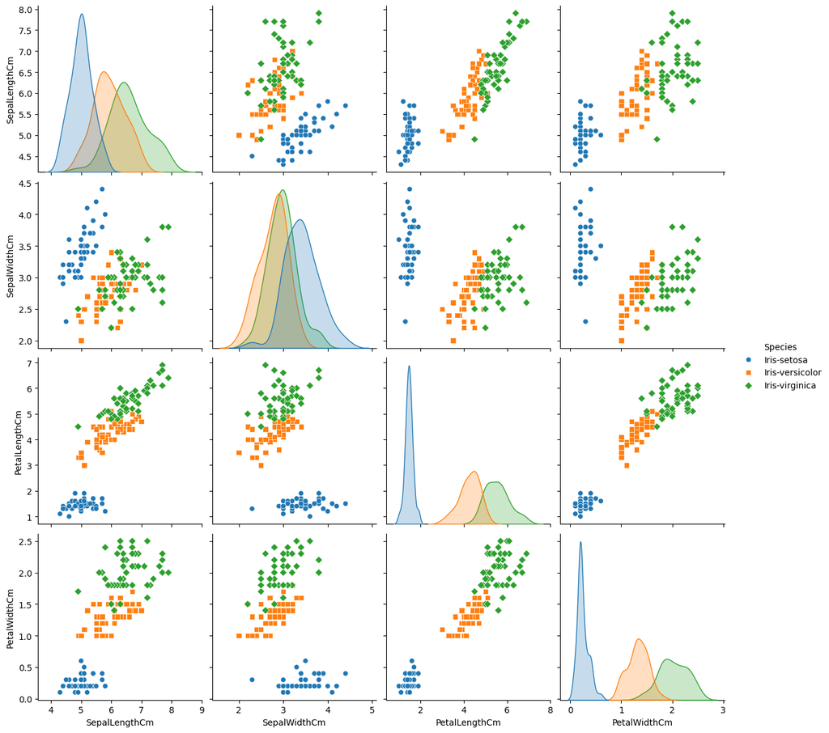

```python
# Create a new figure for the plot.
plt.figure()

# Use Seaborn's pairplot to plot pairwise relationships between features in the dataset.
# 'hue = "Species"' colors the data points based on the 'Species' column.
# 'height = 3' specifies the size of the plots.
# 'markers = ["o", "s", "D"]' uses different markers for different 'Species' values.
sns.pairplot(dataset.drop("Id", axis=1), hue = "Species", height = 3, markers = ["o", "s", "D"])

# Display the plot.
plt.show()
```

**Using correlation table and heatmap**

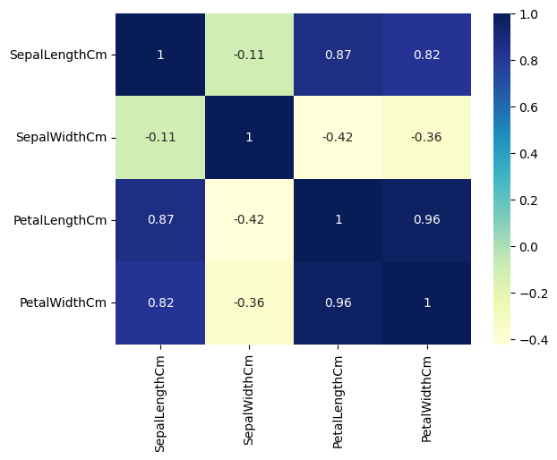

```python
# Let's see the correlation between different variables.
sns.heatmap(dataset.drop(['Species', 'Id'], axis = 1). corr(), cmap="YlGnBu", annot = True)
plt.show()
```

Looking at the two charts above, we can see that `PetalLengthCm` and `PetalWidthCm` have a high correlation.

## 2) Data Preprocessing

```python
# Drop the 'Id' column as it is not needed for classification.
dataset = dataset.drop('Id', axis = 1)
```

#### Determine `features` and `labels`

```python
# Drop the 'Species' column from the dataset and store remaining columns in X (features).
X = dataset.drop('Species', axis = 1)
# Store the 'Species' column in y (target variable).
y = dataset['Species']
```

#### Lable Encoding

`Species` is a categorical variables. Therefore, we need to convert Species into numbers:

- Iris-setosa correspond to 0
- Iris-versicolor correspond to 1
- Iris-virginica correspond to 2

```python
# Convert categorical labels in y to numeric values.
le = LabelEncoder()
y = le.fit_transform(y)
```

#### Splitting dataset into training and test sets

- **Training set**: Used to build the classifier
- **Test set**: Used to evaluate the classifier's performance

```python
# Split the data into training and testing sets.
# The training set will comprise 80%, and the test set will make up 20%.
X_train, X_test, y_train, y_test = train_test_split(X, y, test_size = 0.2, random_state = 0)
```

```python
#120 rows used for training (80%).
X_train.shape
```

```
(120, 4)
```

```python
y_train.shape
```

```
(120,)
```

```python
#30 rows used for testing (20%).
X_test.shape
```

```
(30, 4)
```

```python
y_test.shape
```

```
(30,)
```

## 3) Build a classification model using Random Forest

Using `RandomForestClassifier` from sklearn to build the Random Forest classification model

```python
# Initializing the RandomForest model with 100 trees and fixing the random state to 0 for reproducibility.
rf = RandomForestClassifier(n_estimators=100, random_state=0)
```

```python
# fit data to the model.
rf.fit(X_train, y_train)
```

```
RandomForestClassifier(random_state=0)
```

### Review the results returned by the model

```python
# Number of classes in the Random Forest classifier.
rf.n_classes_
```

```
3
```

```python
# Labels of classifier.
rf.classes_
```

```
array([0, 1, 2])
```

```python
# Total number of features used to build the classifier.
rf.n_features_in_
```

```
4
```

#### Predict the results on the test set

```python
y_pred = rf.predict(X_test)
y_pred
```

```
array([2, 1, 0, 2, 0, 2, 0, 1, 1, 1, 2, 1, 1, 1, 1, 0, 1, 1, 0, 0, 2, 1,
       0, 0, 2, 0, 0, 1, 1, 0])
```

#### Model Evaluation

```python
print(confusion_matrix(y_test, y_pred))
print(classification_report(y_test, y_pred))
```

```
[[11  0  0]
 [ 0 13  0]
 [ 0  0  6]]
              precision    recall  f1-score   support

           0       1.00      1.00      1.00        11
           1       1.00      1.00      1.00        13
           2       1.00      1.00      1.00         6

    accuracy                           1.00        30
   macro avg       1.00      1.00      1.00        30
weighted avg       1.00      1.00      1.00        30
```

```python
# Shows the shape of y_test.
y_test.shape
```

```
(30,)
```

```python
# Shows the shape of y_pred.
y_pred.shape
```

```
(30,)
```

##### Calculate accuracy using `accuracy_score`

```python
accuracy_score(y_test, y_pred)
```

```
1.0
```

##### Using the model to calculate accuracy

```python
# Accuracy of model on testing set.
accuracy_score = rf.score(X_test, y_test) * 100
print('Accuracy of our model is equal ' + str(round(accuracy_score, 2)) + ' %.')
```

```
Accuracy of our model is equal 100.0 %.
```

### Feature Importance

```python
# Feature importance in order.
rf.feature_importances_
```

```
array([0.10282024, 0.03010785, 0.42017676, 0.44689514])
```

```python
# Create a Series object to identify the important features.
feature_imp = pd.Series(rf.feature_importances_,index=X_train.columns).sort_values(ascending=False)
feature_imp
```

```
PetalWidthCm     0.446895
PetalLengthCm    0.420177
SepalLengthCm    0.102820
SepalWidthCm     0.030108
dtype: float64
```

##### Visualize the feature importance

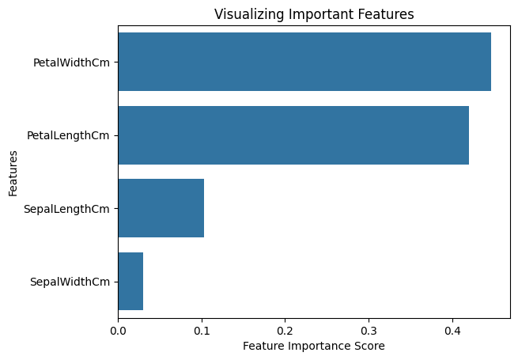

```python
# Creating a bar plot.
sns.barplot(x=feature_imp, y=feature_imp.index)
plt.xlabel('Feature Importance Score')
plt.ylabel('Features')
plt.title("Visualizing Important Features")
plt.show()
```

We can see that `PetalWidthCm` is the most important feature. Additionally, the importance of the `SepalWidthCm` attribute is very low, so we can exclude it and use only the remaining 3 features to build the classifier

## 4) Build the model based on the Selected Features

```python
X_train
```

|  | SepalLengthCm | SepalWidthCm | PetalLengthCm | PetalWidthCm |
| --- | --- | --- | --- | --- |
| 137 | 6.4 | 3.1 | 5.5 | 1.8 |
| 84 | 5.4 | 3.0 | 4.5 | 1.5 |
| 27 | 5.2 | 3.5 | 1.5 | 0.2 |
| 127 | 6.1 | 3.0 | 4.9 | 1.8 |
| 132 | 6.4 | 2.8 | 5.6 | 2.2 |
| ... | ... | ... | ... | ... |
| 9 | 4.9 | 3.1 | 1.5 | 0.1 |
| 103 | 6.3 | 2.9 | 5.6 | 1.8 |
| 67 | 5.8 | 2.7 | 4.1 | 1.0 |
| 117 | 7.7 | 3.8 | 6.7 | 2.2 |
| 47 | 4.6 | 3.2 | 1.4 | 0.2 |

120 rows × 4 columns

```python
# Drop the 'SepalWidthCm' column, only select the remaining 3 columns.
X_train_selected = X_train.drop('SepalWidthCm', axis = 1)
X_test_selected = X_test.drop('SepalWidthCm', axis = 1)
```

```python
X_train_selected
```

|  | SepalLengthCm | PetalLengthCm | PetalWidthCm |
| --- | --- | --- | --- |
| 137 | 6.4 | 5.5 | 1.8 |
| 84 | 5.4 | 4.5 | 1.5 |
| 27 | 5.2 | 1.5 | 0.2 |
| 127 | 6.1 | 4.9 | 1.8 |
| 132 | 6.4 | 5.6 | 2.2 |
| ... | ... | ... | ... |
| 9 | 4.9 | 1.5 | 0.1 |
| 103 | 6.3 | 5.6 | 1.8 |
| 67 | 5.8 | 4.1 | 1.0 |
| 117 | 7.7 | 6.7 | 2.2 |
| 47 | 4.6 | 1.4 | 0.2 |

120 rows × 3 columns

```python
# Build the classifier based on X_train_selected (with only 3 features).
rf2 = RandomForestClassifier(n_estimators=100, random_state=0)
rf2.fit(X_train_selected, y_train)
```

```
RandomForestClassifier(random_state=0)
```

### Model Evaluation

```python
# Accuracy of model.
accuracy_score = rf2.score(X_test_selected, y_test) * 100
print('Accuracy of our model is equal ' + str(round(accuracy_score, 2)) + ' %.')
```

```
Accuracy of our model is equal 100.0 %.
```

We can see that after removing the `SepalWidthCm` feature, the model's accuracy doesn't change significantly. This can be explained by the fact that `SepalWidthCm` is not an important feature, so it can be excluded when building the model.